# Cluster level Statistics for single cell expression data

# Downstream Analysis: Clustering and cluster level statistics

Once the clusters are defined, markers can be found using Differential expression. Here I use `FindAllMarkers` function in order to do that which identifies markers for each process by comparing it to other clusters/groups of cells. It outputs all the cluster level statistics which includes pvalues, adjusted pvalues, average logFC, cluster, etc.

The DotPlot gives a good idea about the genes which are highly expressed across different clusters. Some genes of interest include “dnc”, “apolpp”, “mgl”.

It is also interesting to note how some genes have high expression levels but low percent cell expression meaning they are just highly expressed in one cluster and not in others.

```r
DefaultAssay(ag_combined) <- "RNA"
AG_markers <- FindAllMarkers(ag_combined, only.pos = T, logfc.threshold = 0.25)
```

[output not shown]

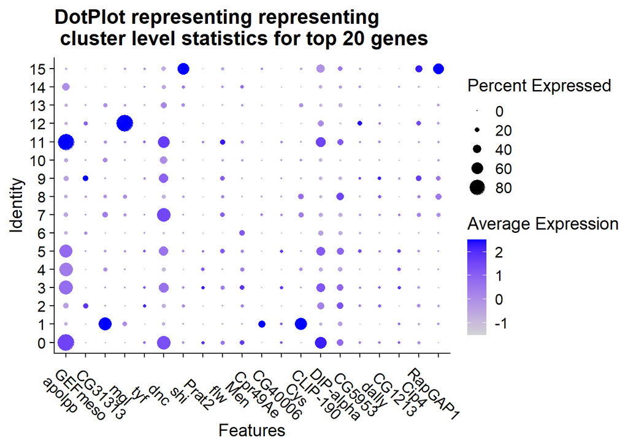

```r
#top 20 genes list
ag_top20 <- AG_markers %>%
  arrange(avg_log2FC)  %>%
  pull(gene) %>%
  .[1:20]

# PNG device
#png("my_plot.png")

#dotplot for visualization
c <- DotPlot(ag_combined, features = ag_top20)
c + labs(title = "DotPlot representing representing \n cluster level statistics for top 20 genes")+theme(axis.text.x = element_text(size = 12, angle = -45))
```

```r
## storing cluster level statistics as csv
ag_stats <- as.data.frame(c$data)
write.csv(ag_stats,file = "clusterLevelStats_results.csv")
saveRDS(ag_combined,"seurat_results.rds")

formattable::formattable(ag_stats)
```

|  | avg.exp | pct.exp | features.plot | id | avg.exp.scaled |
| --- | --- | --- | --- | --- | --- |
| apolpp | 286.8537549 | 86.8971061 | apolpp | 0 | 1.558183687 |
| GEFmeso | 0.7603603 | 3.7781350 | GEFmeso | 0 | -0.494965770 |
| CG31313 | 2.5742086 | 3.0546624 | CG31313 | 0 | -0.461190098 |
| mgl | 0.5812028 | 1.5675241 | mgl | 0 | -0.383385856 |
| tyf | 2.4233598 | 10.3295820 | tyf | 0 | 0.785196321 |
| dnc | 51.3296471 | 68.9710611 | dnc | 0 | 1.356860654 |
| shi | 2.3760100 | 11.0530547 | shi | 0 | -0.134611354 |
| Prat2 | 7.5939016 | 13.2234727 | Prat2 | 0 | 1.896967329 |
| flw | 5.4269556 | 17.2427653 | flw | 0 | 0.583242163 |
| Men | 15.5461486 | 21.7041801 | Men | 0 | 1.773043941 |
| Cpr49Ae | 0.1891019 | 0.4421222 | Cpr49Ae | 0 | -0.447928887 |
| CG40006 | 2.8397664 | 10.8118971 | CG40006 | 0 | 1.292281892 |
| Cys | 1.2541555 | 1.8890675 | Cys | 0 | -0.513477825 |
| CLIP-190 | 44.3528011 | 57.9180064 | CLIP-190 | 0 | 2.238652024 |
| DIP-alpha | 51.6542201 | 31.9935691 | DIP-alpha | 0 | 0.793594412 |
| CG5953 | 2.5186635 | 10.6109325 | CG5953 | 0 | 0.261103146 |
| dally | 2.3201815 | 11.2942122 | dally | 0 | 0.499933614 |
| CG1213 | 6.8005049 | 11.4147910 | CG1213 | 0 | 1.109152745 |
| Cip4 | 3.6421138 | 12.4598071 | Cip4 | 0 | -0.175783940 |
| RapGAP1 | 0.6993072 | 3.2556270 | RapGAP1 | 0 | -0.480683766 |
| apolpp1 | 34.8947486 | 16.0312805 | apolpp | 1 | -0.644893345 |
| GEFmeso1 | 0.6638683 | 3.2258065 | GEFmeso | 1 | -0.541550530 |
| CG313131 | 119.8517430 | 66.9599218 | CG31313 | 1 | 2.500000000 |
| mgl1 | 8.4508370 | 21.0166178 | mgl | 1 | 0.036979535 |
| tyf1 | 0.8280752 | 3.7145650 | tyf | 1 | -0.837726768 |
| dnc1 | 9.1637006 | 14.5650049 | dnc | 1 | -0.847167474 |
| shi1 | 1.0005774 | 4.7898338 | shi | 1 | -0.461942655 |
| Prat21 | 1.0244179 | 2.2482893 | Prat2 | 1 | -0.503478122 |
| flw1 | 1.7496066 | 6.3538612 | flw | 1 | -0.733950453 |
| Men1 | 3.8931750 | 6.2561095 | Men | 1 | -0.697945811 |

[output cut: 290 more lines]

# Challenges faced